# RESQUE Profile for Felix Schönbrodt

**The “fingerprint” of how research is conducted, when only the best work is submitted.**  
*Analysis from 2024-09-18*  
*Academic Age: 14. Analysis based on 10 publications.*

**Note**

This is a preview which shows some visual summaries of the RESQUE indicators. Not all indicators have been covered yet, and things might change substantially.

Some parts of this profile are purely descriptive. For example, it is summarized whether researchers focus on lab or field studies, whether they predominantly work with psychophysiological data or rather focus on questionnaire studies.

Other parts contain, to some extent, an evaluative aspect: For example, research that is reproducible, which allows independent auditing because it provides open data and scripts is, *ceteris paribus*, better than research that does not have these aspects. Research outputs with these objective quality criteria of methodological rigor can gain “bonus points” which are summed across all provided research outputs and contribute to the Rigor Profile Overview.

**Methods: Is the rigor score systematically biased against certain fields?**

We took care not to systematically disadvantage certain fields or research styles. Generally, the rigor score is a relative score, computed as “percentage of maximal points” (POMP) score across all indicators that are applicable. For any indicator, one can choose the option “not applicable” if an indicator *principally* cannot be attained by a research output. The points of such non-applicable indicators are removed from the maximum points and therefore do not lower the computed relative rigor score. However, in order to prevent gaming of this scheme, any “not applicable” claim needs to be justified. Only when the justification is accepted by the committee, the point is removed. With no or insufficient justification, in contrast, the indicator is set to “not available” (=0 points) and the maximum points are not adjusted.

## Submitted research outputs

10 research outputs have been submitted.

The 10 publications had the following methodological type:

| Type of method | # papers |
| --- | --- |
| Computational | 5 |
| Empirical Quantitative | 4 |
| Meta Analysis | 3 |
| Other Method | 2 |
| Theoretical | 3 |

### Team science in publications?

| Team category | Frequency | % |
| --- | --- | --- |
| Single authored | 0 | 0% |
| Small team (<= 5 co-authors) | 8 | 80% |
| Large team (6-15 co-authors) | 0 | 0% |
| Big Team (>= 16 co-authors) | 2 | 20% |

## Types of research data

The applicant submitted 9 papers with empirical data.

| Data type | # of papers |
| --- | --- |
| Behavioral | 2 |
| OtherType | 8 |
| ContentData | 2 |
| QuestionnaireSelfreport | 1 |

### Types of behavioral data

| Data type | # of papers |
| --- | --- |
| Performance | 1 |

## Types of samples

Type of population/sample and representativeness for the 3 papers with own new data collection (“Other” excluded):

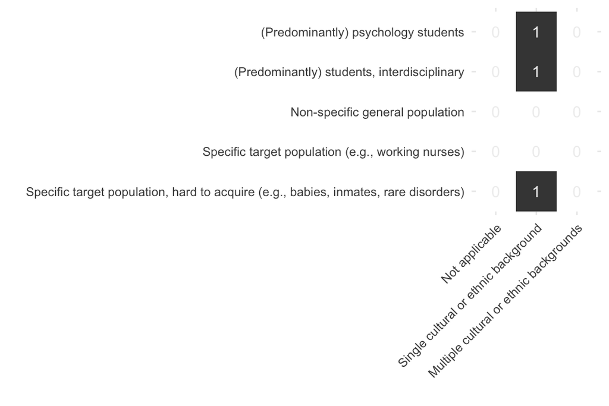

## Contributorship profile (CRediT roles)

Based on 10 submitted publications, this is the self-reported contributorship profile:

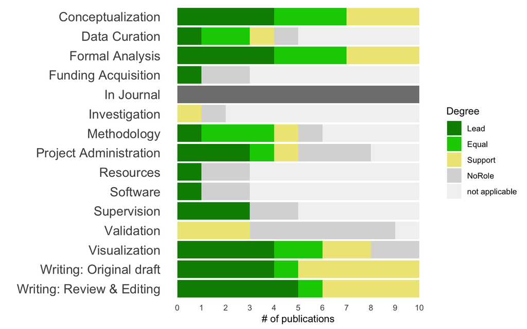

We categorized papers into levels of involvement, based on the degrees of contributorship:

| Involvement.Level | Definition | Publications |
| --- | --- | --- |
| Very High | (>=3 roles as *lead*) OR (>= 5 roles as (*lead* OR *equal*)) | 5 |
| High | (1-2 roles as *lead*) OR (3-4 roles as *equal*) | 4 |
| Medium | (1-2 roles as *equal*) OR (>= 5 roles as *support*) | 1 |
| Low | All other combinations | 0 |

# Indicators of Research Transparency and Reproducibility

## Overview of open research practices

| Open Data Available | Preregistration available | Open Material available | Open Code available | Correctness of computational results has been independently verified |
| --- | --- | --- | --- | --- |

## Rigor profile overview

**Methods: Computation of the relative rigor score**

The relative rigor score (RRS) is computed as a “percentage of maximal points” (POMP) score of multiple indicators. The indicators are grouped into four categories: Open Data, Preregistration, Reproducible Code & Verification, and Open Materials. Indicators that are flagged as “not applicable” are removed from the maximum points and therefore do not lower the RRS.

The general philosophy of RESQUE is: It doesn’t matter so much what kind of research you do - but when you do it, you should do it in a high quality. The radar chart with the **Relative Rigor Score** helps you to see how many quality indicators have been fulfilled in multiple areas of methodological rigor.

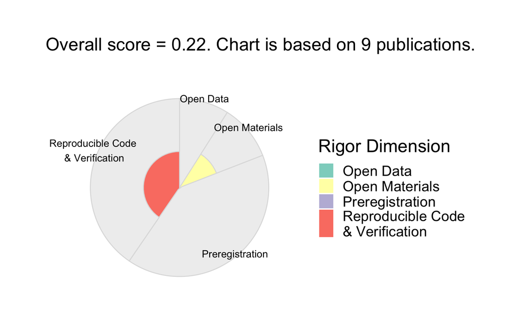

# Scientific impact: Highly popular publications

[BIP! Scholar](https://bip.imsi.athenarc.gr/site/home) (a non-commercial open-source service to facilitate fair researcher assessment) provides **five impact classes** based on norm values:

| 🚀 Top 0.01% | ️🌟 Top 0.1% | ️✨ Top 1% | Top 10% | Average (Bottom 90%) |
| --- | --- | --- | --- | --- |

**Methods: Computation of the Popularity metric**

This indicator reflects impact/attention of an article in the research community at large. It is based on *AttRank*, a variation of PageRank (known from the Google search algorithm) that accounts for the temporal evolution of the citation network. By that, it alleviates the bias against younger publications, which have not had the chance to accumulate a lot of citations. It models a researcher’s preference to read papers which received a lot of attention recently. It was evaluated (and vetted) in its performance to predict the ranking of papers concerning their *future impact* (i.e., citations). For more details, see [BIP! glossary](https://bip.imsi.athenarc.gr/site/indicators) and the references therein.

From 10 submitted papers of Felix Schönbrodt, 9 were in the top 10% popularity class of all papers or better.

| Title | 3 year citation count | Overall citation count | FNCS | Popularity | Candidates' CRediT involvement | Candidates' CRediT main roles |
| --- | --- | --- | --- | --- | --- | --- |
| ️🌟[Bayes factor design analysis: Planning for compelling evidence](https://doi.org/10.3758/s13423-017-1230-y) | 76 | 367 | 47.1 | Top 0.1% | Very High | **Lead:** Conceptualization, Formal Analysis, Visualization, Writing: Original draft, Writing: Review & Editing **Equal:** Methodology |
| ️🌟[At what sample size do correlations stabilize?](https://doi.org/10.1016/j.jrp.2013.05.009) | 90 | 1303 | 85.9 | Top 0.1% | Very High | **Lead:** Conceptualization, Formal Analysis, Methodology, Project Administration, Visualization, Writing: Original draft, Writing: Review & Editing |
| ️✨[Replicability, Robustness, and Reproducibility in Psychological Science](https://doi.org/10.1146/annurev-psych-020821-114157) | 212 | 212 | 194.1 | Top 1% | Medium | NANA |
| ️✨[Correcting for Bias in Psychology: A Comparison of Meta-Analytic Methods](https://doi.org/10.1177/2515245919847196) | 112 | 290 | 55.8 | Top 1% | High | **Lead:** Software **Equal:** Conceptualization, Formal Analysis, Methodology, Project Administration, Visualization, Writing: Original draft, Writing: Review & Editing |
| ️✨[Testing Similarity Effects with Dyadic Response Surface Analysis](https://doi.org/10.1002/per.2169) | 31 | 82 | 11.7 | Top 1% | Very High | **Lead:** Conceptualization, Formal Analysis, Project Administration, Visualization, Writing: Original draft, Writing: Review & Editing |
| [Big little lies: a compendium and simulation of*p*-hacking strategies](https://doi.org/10.1098/rsos.220346) | 24 | 24 | 91.4 | Top 10% | High | NANA |
| [Measuring Implicit Motives with the Picture Story Exercise (PSE): Databases of Expert-Coded German Stories, Pictures, and Updated Picture Norms](https://doi.org/10.1080/00223891.2020.1726936) | 18 | 18 | 4.2 | Top 10% | Very High | **Lead:** Conceptualization, Data Curation, Formal Analysis, Project Administration, Visualization, Writing: Original draft, Writing: Review & Editing |
| [A Series of Meta-Analytic Tests of the Efficacy of Long-Term Psychoanalytic Psychotherapy](https://doi.org/10.1027/1016-9040/a000385) | 9 | 18 | 3.4 | Top 10% | High | **Lead:** Supervision |
| [From Motive Dispositions to States to Outcomes: An Intensive Experience Sampling Study on Communal Motivational Dynamics in Couples](https://doi.org/10.1002/per.2145) | 12 | 18 | 2.4 | Top 10% | Very High | **Lead:** Funding Acquisition, Resources, Supervision, Writing: Review & Editing **Equal:** Conceptualization |

Note:  
FNCS = Field- and age-normalized citation score: This is the factor by which a publication is cited more often than other publications from the same field and the same publication year. A value of 2, for example, indicates that the publication got cited twice as much as comparable publications.

# Internationality and Interdisciplinarity

**Methods: Computation of Internationality and Interdisciplinarity**

The analysis is only based on the submitted publications (not the entire publication list) of the applicant. Publication and co-author data is retrieved from the OpenAlex data base. Note that preprints are not indexed by OpenAlex and therefore do not contribute to this analysis.

- *Internationality* is measured by Pielou’s Evenness Index (Pielou 1966) of the country codes of all co-authors. It considers the 10 most frequent country codes.
- *Interdisciplinarity* is measured by the Evenness Index of the fields (as classified by OpenAlex) of the publications. It considers the 6 most frequent fields.

The evenness indexes are normalized to a scale from 0 (no diversity, everything is one category) to 1 (maximum diversity, all categories are equally represented).

**Internationality**

**Interdisciplinarity**

Only within country co-authors

Broad coauthor network from many countries

Single discipline

Many disciplines

49 unique identifiable co-authors:

- 49% from 7 international countries
- 51% from the same country

2 primary fields:

- Psychology (8)
- Decision Sciences (2)

| Co-authors' Country Code | # of Co-authors |
| --- | --- |
| DE | 25 |
| US | 10 |
| NL | 6 |
| AT | 2 |
| AU | 2 |
| CH | 2 |
| IT | 1 |
| SE | 1 |

The main subfields are (multiple categories per paper are possible):

| Subfield | # of papers |
| --- | --- |
| Experimental and Cognitive Psychology | 6 |
| Clinical Psychology | 5 |
| Applied Psychology | 4 |
| Social Psychology | 2 |
| Sociology and Political Science | 2 |
| Statistics and Probability | 2 |